# Homework #5: SVM and Calibration

## c. Risk Score and Probability (by race)

Repeat the analysis, but this time do so for every race. Produce a set of plots (one per race) and comment on the patterns.

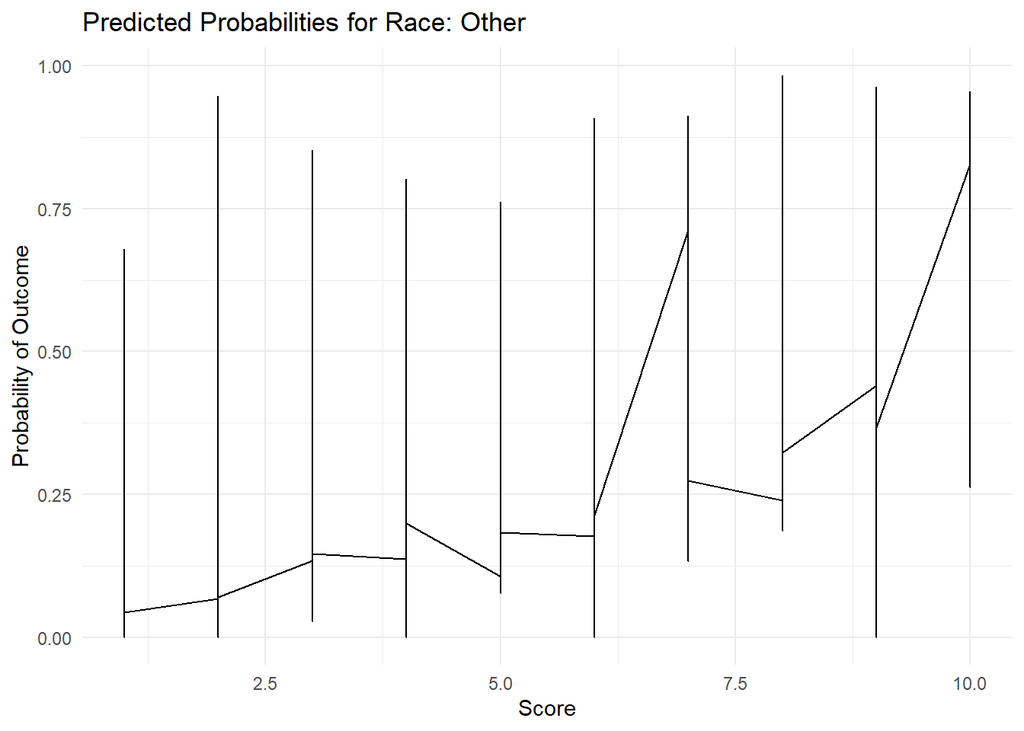

```
$`African-American`
```

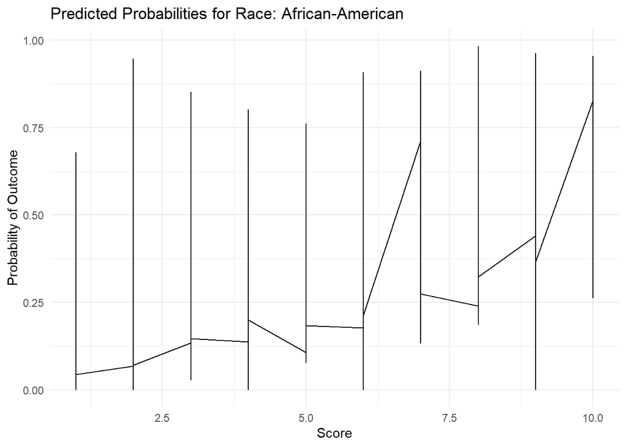

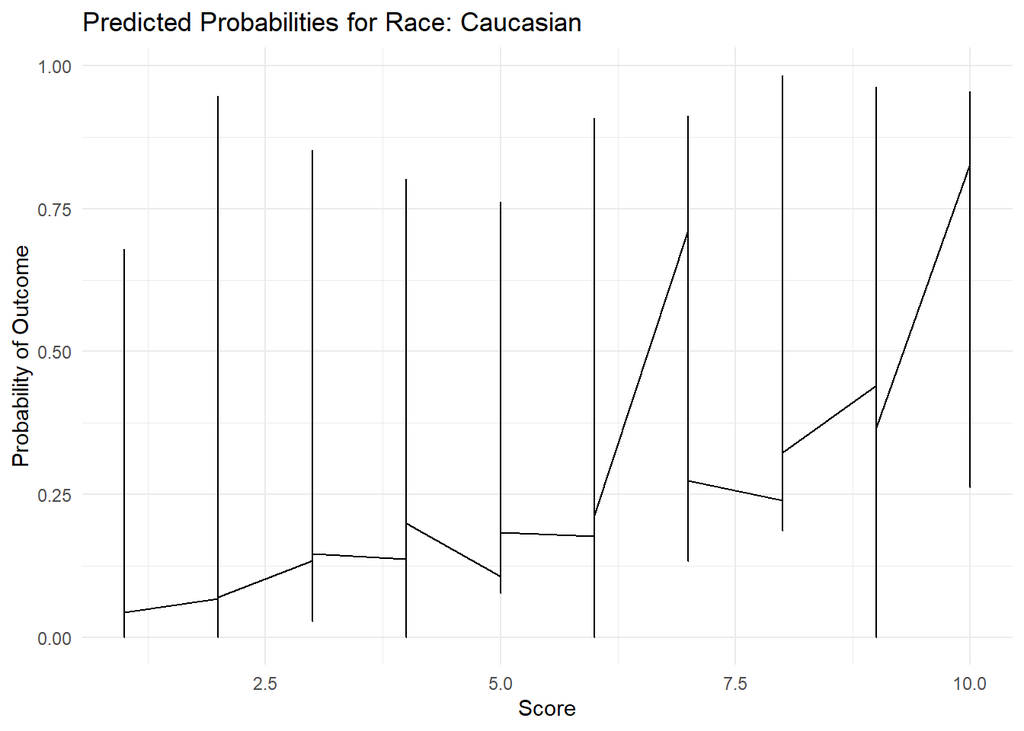

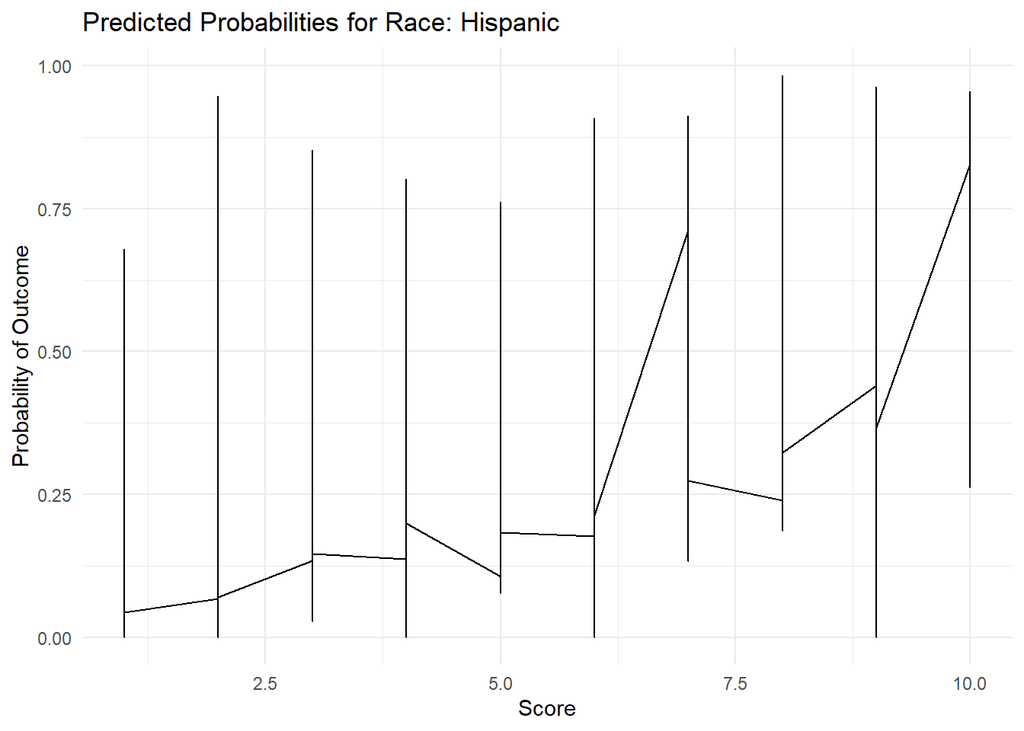

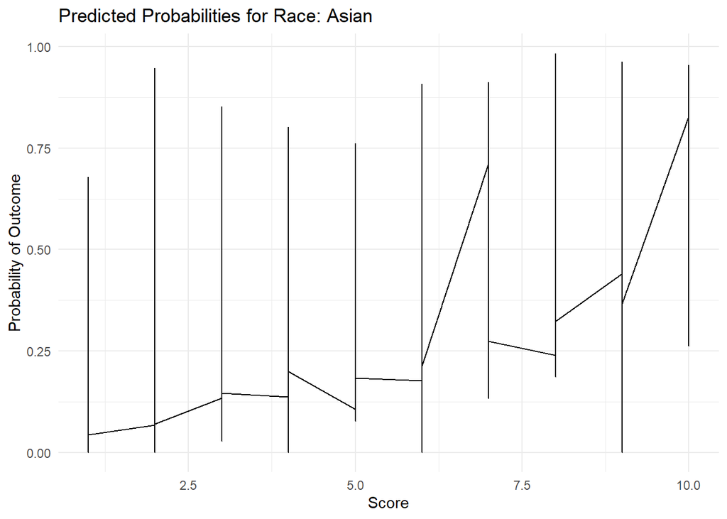

```
$`Native American`
```

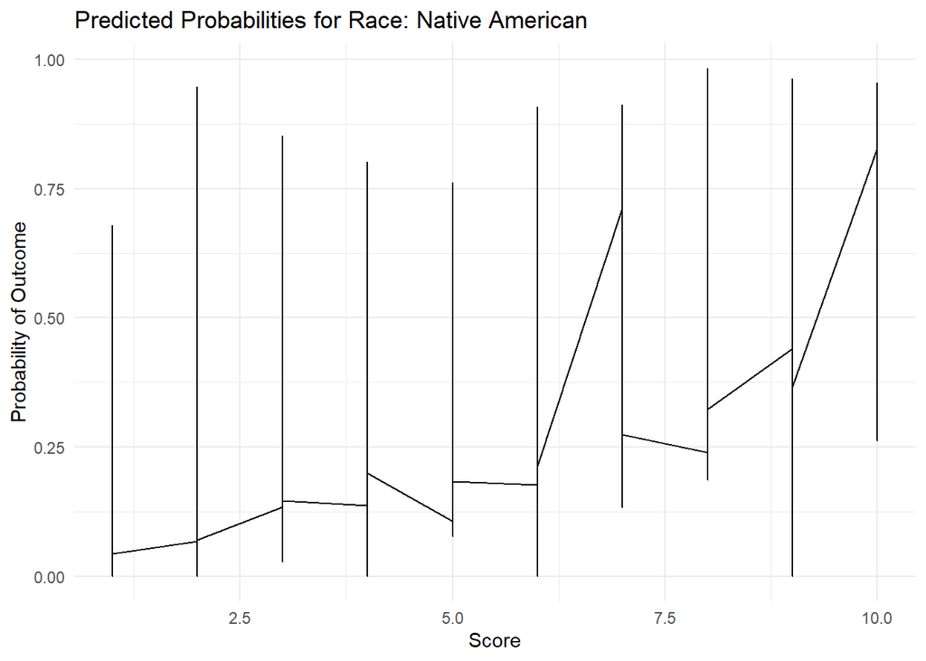

```r
plots = list()

unique_races = unique(risk$race)
for (race in unique_races) {
  race_data = subset(risk, race == race)

  probabilities = predict(fit_lr, newdata = race_data, type = "response")

  standard_errors = sqrt(probabilities * (1 - probabilities) / length(probabilities))
  z = qnorm(0.5)
  lower = probabilities - z * standard_errors
  upper = probabilities + z * standard_errors

  result_table = data.frame(
    Score = race_data$score,
    Probability = probabilities,
    Normal_Lower = lower,
    Normal_Upper = upper
  )

  plots[[race]] = ggplot(result_table, aes(x = Score, y = Probability)) +
    geom_line() +
    geom_ribbon(aes(ymin = Normal_Lower, ymax = Normal_Upper), alpha = 0.2) +
    labs(x = "Score", y = "Probability of Outcome", title = paste("Predicted Probabilities for Race:", race)) +
    theme_minimal()
}

plots
```

## d. ROC Curves

Use the raw COMPAS risk scores to make a ROC curve for each race.

- Are the best discriminating models the ones you expected?
- Are the ROC curves helpful in evaluating the COMPAS risk score?

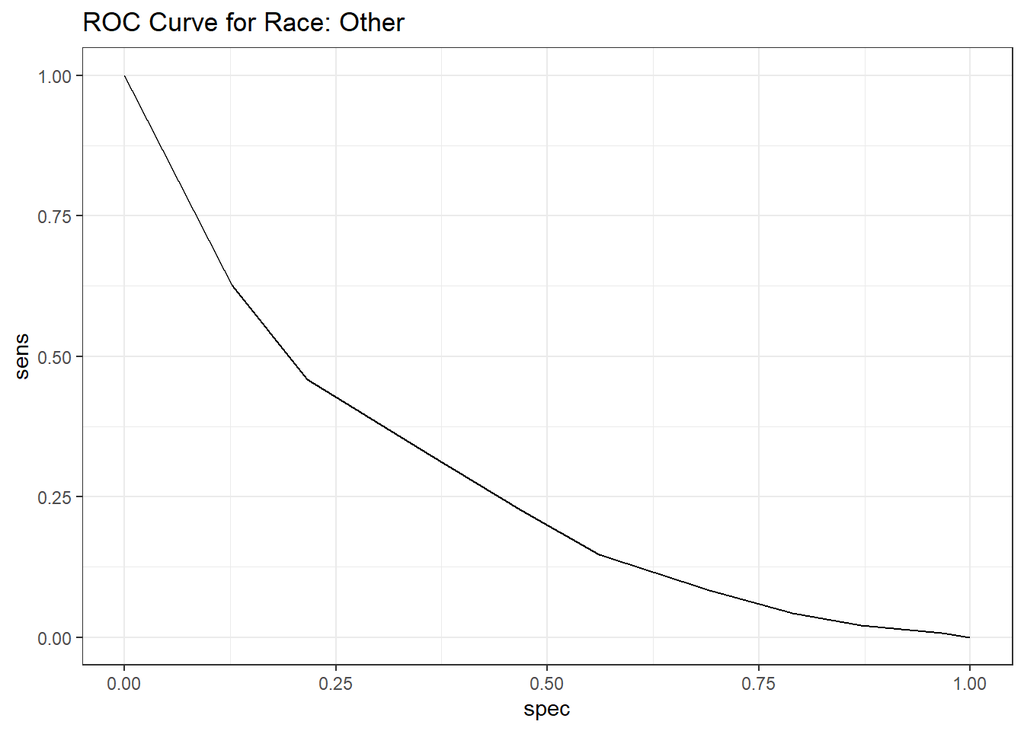

```
$`African-American`
```

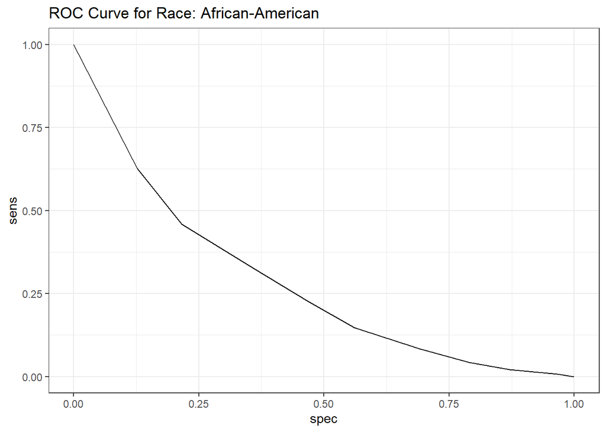

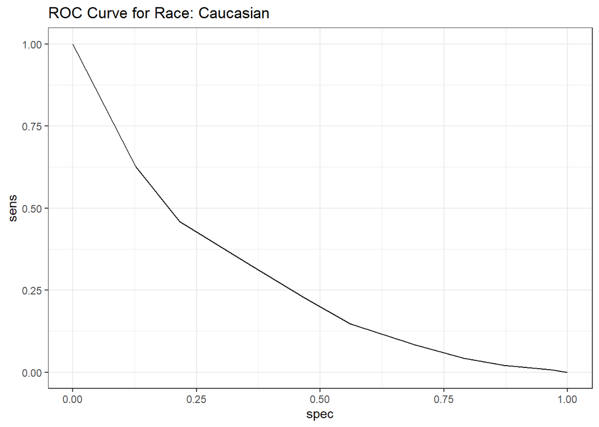

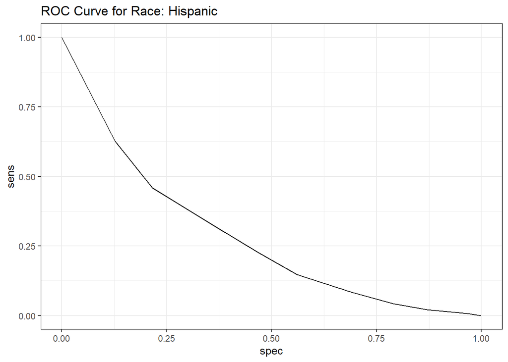

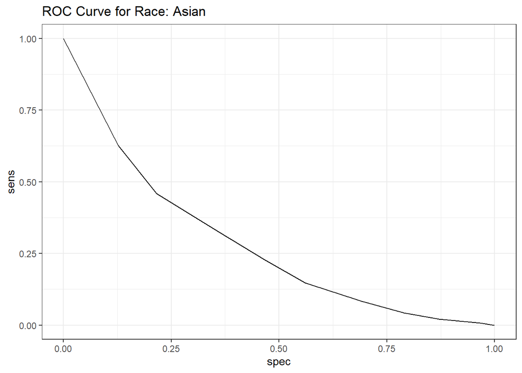

```
$`Native American`
```

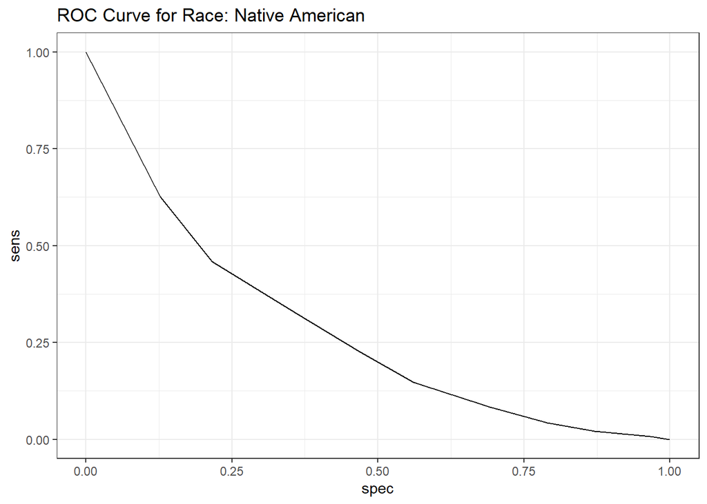

```r
risk$outcome = factor(risk$outcome)

roc_curves_by_race = list()
plots = list()

for (race in unique(risk$race)) {
  subset_data = subset(risk, race == race)

  roc_curves_by_race[[race]] = roc_curve(subset_data,outcome,
                                            score)

  data = data.frame(
    spec = roc_curves_by_race[[race]]$specificity,
    sens = roc_curves_by_race[[race]]$sensitivity
  )

  plots[[race]] = ggplot(data, aes(x = spec, y = sens)) +
    geom_line() +
    labs(title = paste("ROC Curve for Race:", race))
}

plots
```

```r
#The curves, and fro mthe previous plots, seemed to have little coorelation between outcomes. The ROC curves are somewhat helpful as a validation effort against my model results. I'm skeptical if my results are skewed, because the internvals changed however, the overall data stayed the same.
```

# Problem 2: Support Vector Machines (SVM)

Focus on Problem 1, we won’t have an SVM problem this week.